# ラ・リーガの各チームの強さを推定する(作成中)

UPDATE: 2024-01-23 16:05:44.967038

# はじめに

このノートは「ベイズ統計」に関する何らかの内容をまとめ、ベイズ統計への理解を深めていくために作成している。今回はRasmus Bååth先生のブログに記載されているサッカーチームの強さを推定する内容を参考にさせていただき、写経しながら、ところどころ自分用の補足をメモすることで、自分用の補足資料になることを目指す。私の解釈がおかしく、メモが誤っている場合があるので注意。

- [Modeling Match Results in La Liga Using a Hierarchical Bayesian Poisson Model: Part one.](https://www.sumsar.net/blog/2013/07/modeling-match-results-in-la-liga-part-one/)
- [Modeling Match Results in La Liga Using a Hierarchical Bayesian Poisson Model: Part two.](https://www.sumsar.net/blog/2013/07/modeling-match-results-in-la-liga-part-two/)
- [Modeling Match Results in La Liga Using a Hierarchical Bayesian Poisson Model: Part three](https://www.sumsar.net/blog/2013/08/modeling-match-results-in-la-liga-part-three/)

こちらのブログではJAGSを利用しており、再現はStanで行うため、結果は完全に一致しない。また、JAGSとStanでは正規分布のパラメタの与え方が異なるので、そのあたりは修正を行っているが、ブログの数式はそのまま表示しているので、数式とStanモデルでは差異がある点は注意が必要である。

# Modeling Match Results in La Liga Using a Hierarchical Bayesian Poisson Model.

この分析は、

- 1. 将来の試合で起こりうるゴール結果のオッズを計算し、
- 2. チームの信頼できるランキングを作成できるようにする

これが本分析の目的とのこと。まずは必要なデータやパッケージを準備しておく。ブログで使用されている通り、使用するデータはラ・リーガの5つのシーズン(`2008/09, 2009/10, 2010/11, 2011/12, 2012/13`)の試合結果が記録されているデータを利用する。このデータはseR 2013データ分析コンテストの一環として提供されたリーガ・エスパニョーラのデータセット。

```r
library(tidyverse)
library(rstan)
library(patchwork)
library(xtable)
source("plotPost.R")

options(max.print = 999999)
rstan_options(auto_write=TRUE)
options(mc.cores=parallel::detectCores())

set.seed(12345)

# Convenience function to generate the type of column names Jags outputs.
col_name <- function(name, ...) {
  paste0(name, "[", paste(..., sep=",") , "]")
}

load("laliga.RData")

head(laliga)
```

```
##    Season Week               HomeTeam                    AwayTeam HomeGoals
## 1 2008/09    1   Athletic Club Bilbao     Union Deportiva Almeria         1
## 2 2008/09    1        Atlético Madrid                   Málaga CF         4
## 3 2008/09    1          Betis Sevilla Real Club Recreativo Huelva         0
## 4 2008/09    1             CA Osasuna               Villarreal CF         1
## 5 2008/09    1            CD Numancia                FC Barcelona         1
## 6 2008/09    1 Deportivo de La Coruña              Real Madrid CF         2
##   AwayGoals
## 1         3
## 2         0
## 3         1
## 4         1
## 5         0
## 6         1
```

モデリングや可視化で必要になるカラムを作成しておく。`2012/13`シーズンのいくつかのレコードには欠損値が含まれているので、そのレコードは除外しておく。

```r
# -1 Away win, 0 Draw, 1 Home win
laliga$MatchResult <- sign(laliga$HomeGoals - laliga$AwayGoals)
# Creating a data frame d with only the complete match results
# laliga %>% filter(is.na(HomeGoals))
d <- na.omit(laliga)
```

ここではいくつかの特徴(昇格、降格)があるチームをサンプリングしてモデリングを行う。すべてのシーズン、すべてのチームのデータを利用して推定したほうが良いと思うが、あくまでも学習用なので、ここでは時間を考慮して必要なチームのレコードを利用する。

```r
# Sampling
t <- c(
  'Real Valladolid',
  'Atlético Madrid',
  'FC Barcelona',
  'Villarreal CF',
  'FC Sevilla',
  'Real Madrid CF',
  'FC Valencia',
  'Real Zaragoza',
  'CD Tenerife'
  )

d <- d %>%
  filter(HomeTeam %in% t & AwayTeam %in% t)

dim(d)
```

```
## [1] 235   7
```

特徴に関して、下記の通り説明を記載しておく。

- `Villarreal CF`: `2012/13`シーズンは1部リーグではない
- `Real Zaragoza`: `2008/09`シーズンは1部リーグではない
- `Real Valladolid`: `2010/11,2011/12`シーズンは1部リーグではない
- `CD Tenerife`: `2009/10`シーズンのみ1部リーグ

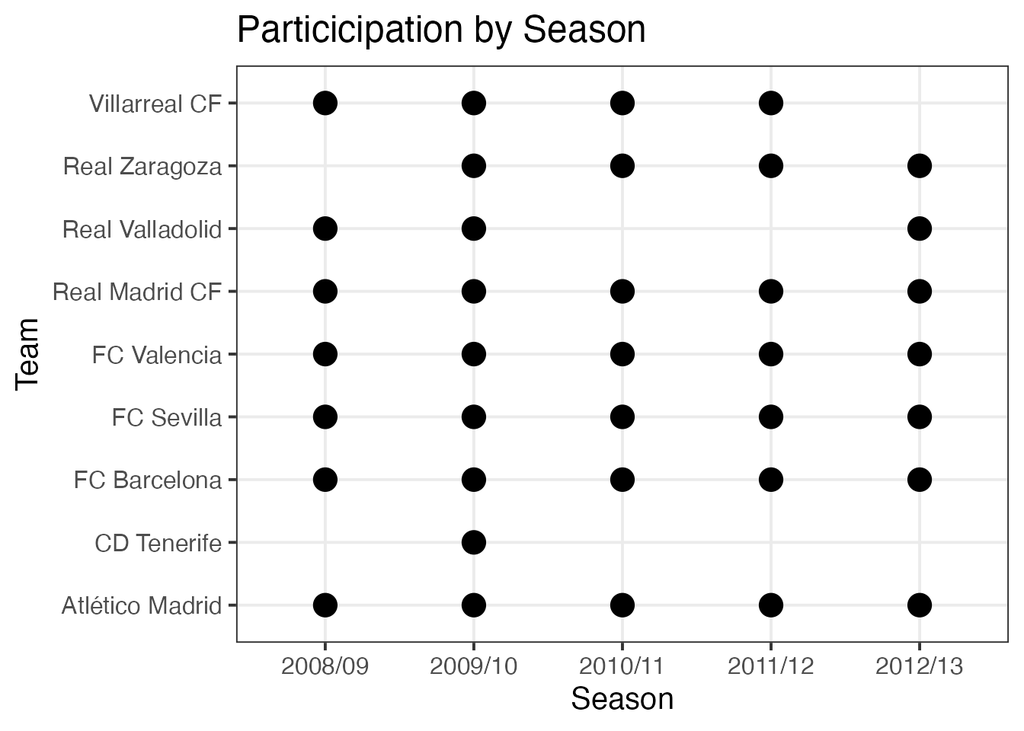

```r
plt_particicipation <- d %>%
  distinct(Season, HomeTeam) %>%
  ggplot(., aes(Season, HomeTeam)) +
  theme_bw(base_size = 15) +
  geom_point(size = 5) +
  labs(xlab = 'Season', y = 'Team', title = 'Particicipation by Season')

plt_particicipation
```

モデリングに関しては3段階に分けて行い、徐々に複雑にしていく。最終的なモデルでもそのままデータが利用できるように、ここでStanに渡すデータを作成する。

```r
teams <- unique(c(d$HomeTeam, d$AwayTeam))
seasons <- unique(d$Season)

data_list <- list(
  HomeGoals = d$HomeGoals,
  AwayGoals = d$AwayGoals,
  HomeTeam = as.numeric(factor(d$HomeTeam, levels = teams)),
  AwayTeam = as.numeric(factor(d$AwayTeam, levels = teams)),
  Season = as.numeric(factor(d$Season, levels=seasons)),
  n_teams = length(teams),
  n_games = nrow(d),
  n_seasons = length(seasons)
  )

data_list
```

```
## $HomeGoals
##   [1] 2 0 6 0 1 4 3 6 1 0 0 0 4 3 2 1 1 1 3 1 3 1 1 4 1 1 3 4 0 2 3 0 4 2 2 2 0
##  [38] 3 3 1 3 3 2 1 4 2 5 1 0 2 3 2 2 0 4 6 5 2 3 3 1 3 1 3 1 1 2 1 6 2 1 0 0 4
##  [75] 4 0 0 4 1 2 2 2 2 1 6 4 1 3 1 3 1 2 2 3 3 3 3 0 0 0 2 2 2 3 1 3 1 3 4 2 2
## [112] 4 1 3 1 1 1 3 2 0 2 5 1 2 2 3 1 1 5 0 2 1 1 1 4 3 1 0 2 0 3 1 1 4 1 0 3 0
## [149] 5 1 1 3 3 2 2 1 5 0 1 2 2 5 1 0 2 0 3 0 3 4 2 4 0 1 2 2 3 3 0 0 1 5 1 1 1
## [186] 2 0 1 1 1 0 1 1 3 1 3 1 0 1 0 1 1 2 2 2 2 2 2 4 1 3 4 1 2 2 4 1 2 2 0 2 1
## [223] 4 0 2 2 2 4 1 1 2 0 0 1 1
##
## $AwayGoals
##   [1] 1 1 1 1 2 4 2 0 0 0 3 3 0 4 0 0 0 2 1 0 3 2 0 3 2 1 2 1 1 0 1 0 0 4 2 6 2
##  [38] 3 0 0 2 1 0 0 1 4 2 2 2 2 0 1 1 0 2 1 0 3 2 1 2 1 0 3 1 2 3 1 0 1 1 5 4 0
##  [75] 1 0 3 2 3 1 0 1 1 1 2 1 5 2 1 0 4 4 2 2 0 0 0 2 0 2 1 0 1 1 2 1 4 1 1 3 0
## [112] 0 0 3 2 1 0 1 1 2 0 0 1 0 0 1 2 1 0 3 0 0 3 0 2 0 2 1 2 1 1 0 1 0 2 1 1 1
## [149] 0 1 0 2 6 3 6 3 0 6 0 2 2 0 0 0 2 0 0 1 1 0 3 1 1 3 6 2 0 1 0 0 2 1 2 2 1
```

[output cut: 38 more lines]

数字とチーム名の対応は下記の通りである。

```r
data.frame(
  no = as.numeric(factor(unique(d$HomeTeam), levels=teams)),
  teams
  )
```

```
##   no           teams
## 1  1 Real Valladolid
## 2  2 Atlético Madrid
## 3  3    FC Barcelona
## 4  4   Villarreal CF
## 5  5      FC Sevilla
## 6  6  Real Madrid CF
## 7  7     FC Valencia
## 8  8   Real Zaragoza
## 9  9     CD Tenerife
```

## Modeling Match Results: Iteration 1

サッカーの試合はポアソン分布に従うと一般的に知られている。サッカーの試合はアディショナルタイムがあれど90分という単位時間があり、そこで得点という事象が発生する回数を表す離散確率分布がポアソン分布。今回のデータも例に漏れず、ポアソン分布に従っていると仮定しても問題はなさそうである。青棒が観測値、赤線がホームゴールの平均値を$\lambda$とするポアソン分布。可視化はしていないが、ホームゴールだけでなく、アウェイゴールもポアソン分布に従っている。

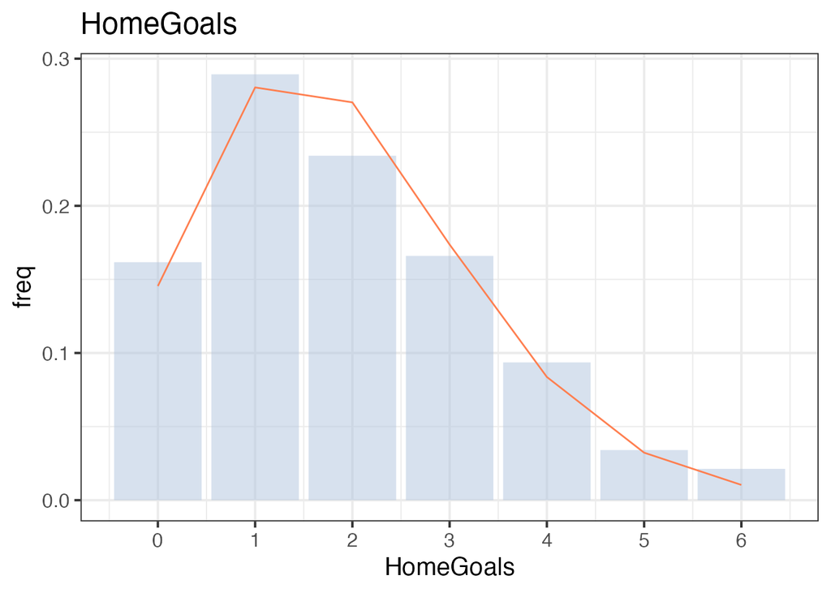

```r
df_homegoals <- d %>%
  group_by(HomeGoals) %>%
  count() %>%
  ungroup() %>%
  mutate(
    freq = n/sum(n),
    prob = dpois(HomeGoals, mean(d$HomeGoals))
    )

ggplot() +
  theme_bw(base_size = 15) +
  geom_bar(data = df_homegoals, aes(HomeGoals, freq), stat = 'identity', fill = 'lightsteelblue', alpha = 1/2) +
  geom_line(data = df_homegoals, aes(HomeGoals, prob), stat = 'identity', col = 'coral') +
  scale_x_continuous(breaks = 0:10) +
  labs(title = 'HomeGoals')
```

ブログで紹介されている1つ目のモデルを利用する。全てのチームが同じように優れているわけではなく、全てのチームが潜在的なスキル(=強さ)を持っていると仮定する。ここで、あるチームのスキルから相手チームのスキルを引いたものが試合の予測となるとする。ゴール数はポアソン分布と仮定できる。チーム$i$がチーム$j$と対戦したときののゴール数の分布は次のようになる。ここでベースラインは、両チームの実力が等しい場合の平均ゴール数である。

$$\begin{eqnarray}
Goals &\sim& \text{Poisson}(\lambda) \\
\log(\lambda) &=& \text{baseline} + \text{skill}_i -
\text{skill}_j \\
\end{eqnarray}$$

ホームチーム$i$とアウェイチーム$j$の試合のゴール結果は次のようにモデル化される。

$$\begin{eqnarray}
HomeGoals_{i,j} &\sim& \text{Poison}(\lambda_{\text{home},i,j})
\\
AwayGoals_{i,j} &\sim& \text{Poison}(\lambda_{\text{away},i,j})
\\
\log(\lambda_{\text{home},i,j}) &=& \text{baseline} +
\text{skill}_i - \text{skill}_j \\
\log(\lambda_{\text{away},i,j}) &=& \text{baseline} +
\text{skill}_j - \text{skill}_i
\end{eqnarray}$$
これにいくつかの事前分布を加える。ベースラインと全$n$チームのスキルに関する事前分布は下記の通り。

$$\begin{eqnarray}
\text{baseline} &\sim& \text{Normal}(0, 4^2) \\
\text{skill}_{1 \ldots n} &\sim& \text{Normal}(\mu_\text{teams},
\sigma_{\text{teams}}^2) \\
\mu_\text{teams} &\sim& \text{Normal}(0, 4^2) \\
\sigma_\text{teams} &\sim& \text{Uniform}(0, 3) \\
\end{eqnarray}$$
今回ここで推定する際は、$\mu_{teams}$は利用しておらず、また、JAGSは分散の代わりに精度(分散の逆数)で正規分布をパラメタ化するが、ここでは、Stanを利用していることもあり、平均0、標準偏差$\sigma_{teams}$の正規分布を代わりに利用している。さらに、ブログでは1つのチームのスキルを定数0に固定しているが、ここでは階層モデルのようにチームの強さは特定の正規分布から生成されるゆるい制約を仮定し、変更している。

```
parameters {
  real baseline;             // ベースラインのパラメータ
  real<lower=0> group_sigma; // グループの標準偏差
  // real group_skill;       // グループのスキル
  real skill[n_teams];       // 各チームのスキル
}

transformed parameters {
  matrix[n_teams, n_teams] lambda_home; // ホームチームの得点率行列
  matrix[n_teams, n_teams] lambda_away; // アウェイチームの得点率行列

  for (home_i in 1:n_teams) {
    for (away_i in 1:n_teams) {
      lambda_home[home_i, away_i] = exp(baseline + skill[home_i] - skill[away_i]);
      lambda_away[home_i, away_i] = exp(baseline + skill[away_i] - skill[home_i]);
    }
  }
}

model {
  // group_skill ~ normal(0, 4);
  group_sigma ~ uniform(0, 3);
  baseline ~ normal(0, 4);

  for (n in 1:n_teams) {
    skill[n] ~ normal(0, group_sigma);
  }

  for (i in 1:n_games) {
    HomeGoals[i] ~ poisson(lambda_home[HomeTeam[i], AwayTeam[i]]);
    AwayGoals[i] ~ poisson(lambda_away[HomeTeam[i], AwayTeam[i]]);
  }
}
```

```r
model1 <- stan_model('model1.stan')
```

`sampling()`関数でサンプリングする。

```r
fit1 <- sampling(object = model1, data = data_list, seed = 1989, chains = 4, iter = 10000, thin = 2)
```

推定結果を確認する。

```r
print(fit1, prob = c(0.025, 0.5, 0.975), digits_summary = 2)
```

```
## Inference for Stan model: anon_model.
## 4 chains, each with iter=10000; warmup=5000; thin=2;
## post-warmup draws per chain=2500, total post-warmup draws=10000.
##
##                     mean se_mean   sd    2.5%     50%   97.5% n_eff Rhat
## baseline            0.41    0.00 0.04    0.33    0.41    0.48  8643    1
## group_sigma         0.39    0.00 0.13    0.22    0.36    0.72  6887    1
## skill[1]           -0.19    0.00 0.16   -0.51   -0.19    0.12  4172    1
## skill[2]           -0.01    0.00 0.15   -0.31   -0.01    0.29  4005    1
## skill[3]            0.59    0.00 0.15    0.29    0.58    0.90  4023    1
## skill[4]           -0.05    0.00 0.15   -0.35   -0.05    0.25  4051    1
## skill[5]           -0.02    0.00 0.15   -0.32   -0.01    0.28  3995    1
## skill[6]            0.38    0.00 0.15    0.09    0.38    0.68  4034    1
## skill[7]            0.00    0.00 0.15   -0.30    0.00    0.30  3996    1
## skill[8]           -0.26    0.00 0.15   -0.57   -0.26    0.04  4136    1
## skill[9]           -0.45    0.00 0.18   -0.81   -0.45   -0.11  4809    1
## lambda_home[1,1]    1.50    0.00 0.06    1.39    1.50    1.62  8646    1
## lambda_home[1,2]    1.26    0.00 0.15    0.99    1.25    1.57  7729    1
## lambda_home[1,3]    0.69    0.00 0.09    0.54    0.69    0.88  8333    1
## lambda_home[1,4]    1.31    0.00 0.16    1.03    1.30    1.64  8295    1
## lambda_home[1,5]    1.27    0.00 0.15    1.00    1.26    1.57  8277    1
## lambda_home[1,6]    0.85    0.00 0.10    0.66    0.85    1.08  8165    1
## lambda_home[1,7]    1.25    0.00 0.14    0.98    1.24    1.55  7796    1
## lambda_home[1,8]    1.62    0.00 0.19    1.28    1.61    2.02  8039    1
## lambda_home[1,9]    1.96    0.00 0.30    1.44    1.94    2.60  8307    1
## lambda_home[2,1]    1.82    0.00 0.21    1.44    1.81    2.25  8212    1
## lambda_home[2,2]    1.50    0.00 0.06    1.39    1.50    1.62  8646    1
## lambda_home[2,3]    0.83    0.00 0.09    0.67    0.83    1.02  8549    1
## lambda_home[2,4]    1.57    0.00 0.16    1.27    1.56    1.92  8387    1
## lambda_home[2,5]    1.52    0.00 0.15    1.24    1.51    1.84  8523    1
## lambda_home[2,6]    1.02    0.00 0.11    0.83    1.02    1.25  8647    1
## lambda_home[2,7]    1.49    0.00 0.15    1.21    1.49    1.81  8457    1
## lambda_home[2,8]    1.94    0.00 0.20    1.58    1.93    2.36  8532    1
## lambda_home[2,9]    2.36    0.00 0.34    1.76    2.33    3.09  8113    1
## lambda_home[3,1]    3.29    0.00 0.35    2.65    3.28    4.03  8234    1
## lambda_home[3,2]    2.74    0.00 0.25    2.27    2.73    3.25  8629    1
## lambda_home[3,3]    1.50    0.00 0.06    1.39    1.50    1.62  8646    1
## lambda_home[3,4]    2.84    0.00 0.27    2.35    2.83    3.40  8182    1
## lambda_home[3,5]    2.76    0.00 0.25    2.30    2.74    3.26  8575    1
## lambda_home[3,6]    1.86    0.00 0.18    1.53    1.85    2.22  8763    1
```

[output cut: 129 more lines]

```
## lambda_away[9,1]    1.96    0.00 0.30    1.44    1.94    2.60  8307    1
## lambda_away[9,2]    2.36    0.00 0.34    1.76    2.33    3.09  8113    1
## lambda_away[9,3]    4.27    0.01 0.60    3.21    4.23    5.56  8294    1
## lambda_away[9,4]    2.27    0.00 0.33    1.68    2.25    2.99  7982    1
## lambda_away[9,5]    2.34    0.00 0.34    1.74    2.32    3.07  8035    1
## lambda_away[9,6]    3.47    0.01 0.49    2.59    3.44    4.52  8030    1
## lambda_away[9,7]    2.38    0.00 0.34    1.77    2.35    3.11  7902    1
## lambda_away[9,8]    1.83    0.00 0.27    1.36    1.81    2.41  8459    1
## lambda_away[9,9]    1.50    0.00 0.06    1.39    1.50    1.62  8646    1
## lp__             -315.57    0.03 2.40 -321.02 -315.26 -311.84  5760    1
##
## Samples were drawn using NUTS(diag_e) at Tue Jan 23 16:05:50 2024.
## For each parameter, n_eff is a crude measure of effective sample size,
## and Rhat is the potential scale reduction factor on split chains (at
## convergence, Rhat=1).
```

MCMCサンプルを使って、FCセビージャとFCバレンシアのトレース・プロットとスキル・パラメータの分布を可視化しておく。

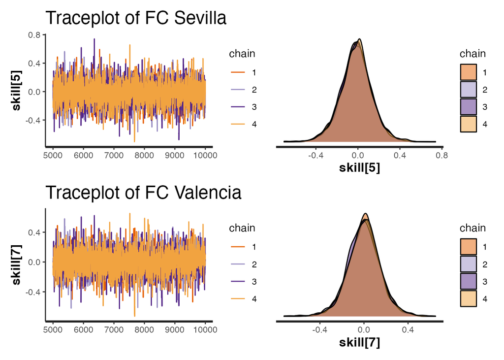

```r
plt_a <- stan_trace(fit1,
           pars = col_name("skill", which(teams == "FC Sevilla")),
           separate_chains = TRUE) + ggtitle('Traceplot of FC Sevilla')

plt_b <- stan_dens(fit1,
           pars = col_name("skill", which(teams == "FC Sevilla")),
           separate_chains = TRUE)

plt_c <- stan_trace(fit1,
           pars = col_name("skill", which(teams == "FC Valencia")),
           separate_chains = TRUE) + ggtitle('Traceplot of FC Valencia')

plt_d <- stan_dens(fit1,
           pars = col_name("skill", which(teams == "FC Valencia")),
           separate_chains = TRUE)

(plt_a | plt_b) / (plt_c | plt_d)
```

セビージャとバレンシアは似たようなスキルを持っているものの、バレンシアの方がわずかに強いと推定されている。MCMCサンプルを使ってチーム間の試合をシミュレートして、ゴール数の分布や、ホームチームの勝利、アウェイチームの勝利、引き分けの確率を見ることもできる。

```r
# ホームチーム名、アウェイチーム名、MCMCサンプルが格納されたmsオブジェクトを受け取る
# MCMCサンプルからモデルのパラメータを取り出し、ホームチームとアウェイチームのスキルを取り出し
# ポアソン分布からランダムサンプリングを行い、予測されたホームチームとアウェイチームの得点を生成
# plot_goals関数を使用してこれらの予測された得点の分布を可視化

ms1 <- rstan::extract(fit1)

plot_pred_comp1 <- function(home_team, away_team, ms) {
  old_par <- par(mfrow = c(2, 4))

  baseline <- ms$baseline
  home_skill <- ms$skill[, which(teams == home_team)]
  away_skill <- ms$skill[, which(teams == away_team)]
  home_goals_sim <- rpois(length(ms$lp__), exp(baseline + home_skill - away_skill))
  away_goals_sim <- rpois(length(ms$lp__), exp(baseline + away_skill - home_skill))

  plot_goals(home_goals_sim, away_goals_sim)

  home_goals_obs <- d$HomeGoals[ d$HomeTeam == home_team & d$AwayTeam == away_team]
  away_goals_obs <- d$AwayGoals[ d$HomeTeam == home_team & d$AwayTeam == away_team]

  plot_goals(home_goals_obs, away_goals_obs)

  par(old_par)
}

plot_goals <- function(home_goals, away_goals) {
  n_matches <- length(home_goals)
  goal_diff <- home_goals - away_goals
  match_result <- ifelse(goal_diff < 0, "away_win", ifelse(goal_diff > 0, "home_win", "equal"))
  hist(home_goals, xlim=c(-0.5, 10), breaks=(0:100) - 0.5)
  hist(away_goals, xlim=c(-0.5, 10), breaks=(0:100) - 0.5)
  hist(goal_diff, xlim=c(-6, 6), breaks=(-100:100) - 0.5 )
  barplot(table(match_result) / n_matches , ylim=c(0, 1))
}
```

バレンシア(Home) vs セビージャ(Away)の結果をシミュレートし、`laliga`データの任意の試合の実際の結果と一緒に予測結果をプロットする。

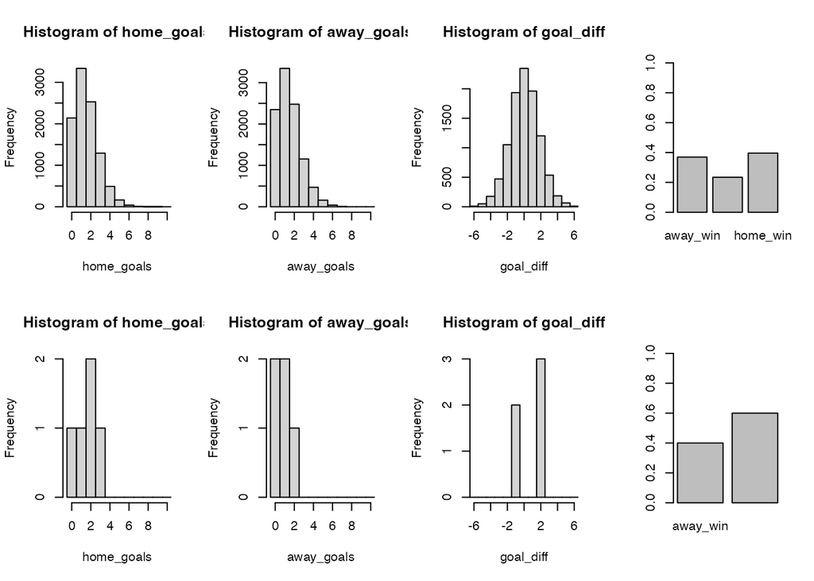

```r
plot_pred_comp1(home_team = 'FC Valencia', away_team = 'FC Sevilla', ms = ms1)
```

過去データはサンプリングしているので、あまりレコードがない。そのため、シュミレーションと似ているかの判断ができないが、シミュレーションではバレンシアの方がセビージャよりわずかに高い確率で勝つことを示している。ホームとアウェイを入れ替えて、セビージャ(Home) vs バレンシア(Away)とする。

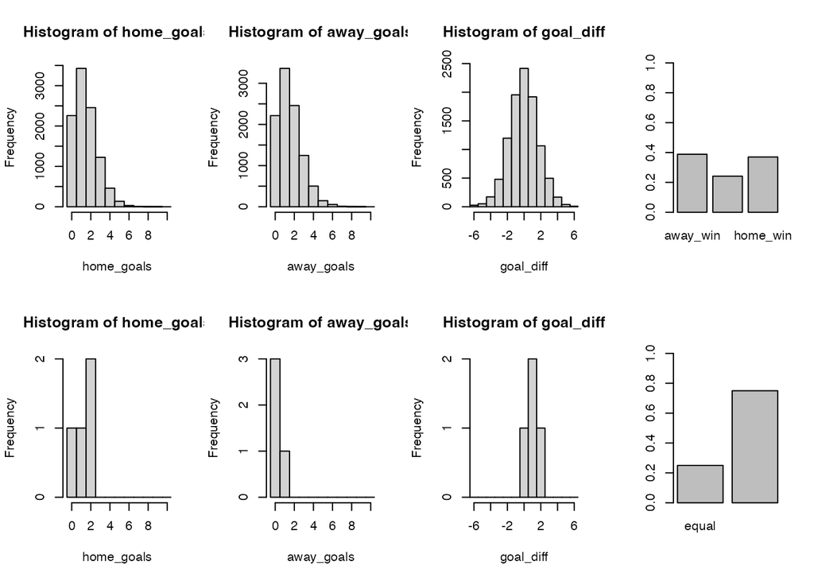

```r
plot_pred_comp1(home_team = 'FC Sevilla', away_team = 'FC Valencia', ms = ms1)
```

ここで現在のモデルに問題があることがわかる。シミュレーションデータは、ホームチームとアウェイチームが入れ替えても結果は変わらない。過去のデータを見ると、セビージャがバレンシアに勝つのはホームチームである場合が多い。ホームチームであることの利点を考慮しているモデルが必要である。

## Modeling Match Results: Iteration 2

ホームアドバンテージを考慮するためのモデルの変更は、ベースラインをホームベースラインとアウェイベースラインの2つに分けること。

```
parameters {
  real home_baseline;        // ホームチームのベースラインのパラメータ
  real away_baseline;        // アウェイチームのベースラインのパラメータ
  real skill[n_teams];       // 各チームのスキル
  real<lower=0> group_sigma; // グループの標準偏差
  // real group_skill;       // グループのスキル
}

transformed parameters {
  matrix[n_teams, n_teams] lambda_home; // ホームチームの得点率行列
  matrix[n_teams, n_teams] lambda_away; // アウェイチームの得点率行列

  for (home_i in 1:n_teams) {
    for (away_i in 1:n_teams) {
      lambda_home[home_i, away_i] = exp(home_baseline + skill[home_i] - skill[away_i]);
      lambda_away[home_i, away_i] = exp(away_baseline + skill[away_i] - skill[home_i]);
    }
  }
}
```

変更したモデルでサンプリングする。

```r
model2 <- stan_model('model2.stan')
```

`sampling()`関数でサンプリングする。

```r
fit2 <- sampling(object = model2, data = data_list, seed = 1989, chains = 4, iter = 10000, thin = 2)
```

推定結果を確認する。

```r
ms2 <- rstan::extract(fit2)
print(fit2, prob = c(0.025, 0.5, 0.975), digits_summary = 2)
```

```
## Inference for Stan model: anon_model.
## 4 chains, each with iter=10000; warmup=5000; thin=2;
## post-warmup draws per chain=2500, total post-warmup draws=10000.
##
##                     mean se_mean   sd    2.5%     50%   97.5% n_eff Rhat
## home_baseline       0.56    0.00 0.05    0.47    0.57    0.66  9955    1
## away_baseline       0.22    0.00 0.06    0.10    0.22    0.33  9344    1
## skill[1]           -0.20    0.00 0.16   -0.53   -0.20    0.11  4271    1
## skill[2]           -0.01    0.00 0.15   -0.32   -0.01    0.30  4216    1
## skill[3]            0.59    0.00 0.15    0.28    0.58    0.90  4293    1
## skill[4]           -0.05    0.00 0.15   -0.36   -0.05    0.26  4284    1
## skill[5]           -0.02    0.00 0.15   -0.33   -0.02    0.29  4233    1
## skill[6]            0.38    0.00 0.15    0.08    0.38    0.70  4216    1
## skill[7]            0.00    0.00 0.15   -0.32    0.00    0.30  4100    1
## skill[8]           -0.26    0.00 0.16   -0.58   -0.26    0.05  4264    1
## skill[9]           -0.45    0.00 0.18   -0.82   -0.44   -0.11  4808    1
## group_sigma         0.39    0.00 0.13    0.22    0.36    0.71  6228    1
## lambda_home[1,1]    1.76    0.00 0.09    1.59    1.76    1.94  9953    1
## lambda_home[1,2]    1.46    0.00 0.18    1.15    1.45    1.83  8555    1
## lambda_home[1,3]    0.81    0.00 0.11    0.62    0.80    1.03  8452    1
## lambda_home[1,4]    1.52    0.00 0.19    1.18    1.51    1.93  8677    1
## lambda_home[1,5]    1.47    0.00 0.18    1.15    1.47    1.85  8239    1
## lambda_home[1,6]    0.99    0.00 0.13    0.77    0.98    1.26  8507    1
## lambda_home[1,7]    1.45    0.00 0.18    1.14    1.44    1.83  8570    1
## lambda_home[1,8]    1.88    0.00 0.23    1.47    1.87    2.35  8212    1
## lambda_home[1,9]    2.28    0.00 0.36    1.66    2.25    3.05  8548    1
## lambda_home[2,1]    2.14    0.00 0.24    1.71    2.13    2.66  8522    1
## lambda_home[2,2]    1.76    0.00 0.09    1.59    1.76    1.94  9953    1
## lambda_home[2,3]    0.98    0.00 0.11    0.78    0.97    1.20  9032    1
## lambda_home[2,4]    1.84    0.00 0.19    1.49    1.83    2.25  8812    1
## lambda_home[2,5]    1.78    0.00 0.19    1.45    1.77    2.16  8957    1
## lambda_home[2,6]    1.20    0.00 0.13    0.96    1.19    1.47  8955    1
## lambda_home[2,7]    1.76    0.00 0.18    1.43    1.75    2.15  8885    1
## lambda_home[2,8]    2.27    0.00 0.24    1.83    2.26    2.77  8809    1
## lambda_home[2,9]    2.75    0.00 0.40    2.05    2.72    3.63  8641    1
## lambda_home[3,1]    3.88    0.00 0.44    3.10    3.87    4.80  7878    1
## lambda_home[3,2]    3.20    0.00 0.31    2.64    3.19    3.86  9034    1
## lambda_home[3,3]    1.76    0.00 0.09    1.59    1.76    1.94  9953    1
## lambda_home[3,4]    3.34    0.00 0.34    2.72    3.32    4.03  8825    1
## lambda_home[3,5]    3.23    0.00 0.31    2.65    3.22    3.86  9122    1
```

[output cut: 130 more lines]

```
## lambda_away[9,1]    1.61    0.00 0.26    1.17    1.59    2.17  8375    1
## lambda_away[9,2]    1.95    0.00 0.29    1.44    1.93    2.57  8564    1
## lambda_away[9,3]    3.53    0.01 0.53    2.61    3.49    4.66  9121    1
## lambda_away[9,4]    1.87    0.00 0.29    1.37    1.85    2.48  8834    1
## lambda_away[9,5]    1.93    0.00 0.29    1.41    1.91    2.56  8637    1
## lambda_away[9,6]    2.88    0.00 0.43    2.12    2.85    3.78  8663    1
## lambda_away[9,7]    1.96    0.00 0.29    1.45    1.93    2.58  8915    1
## lambda_away[9,8]    1.52    0.00 0.23    1.11    1.50    2.02  8881    1
## lambda_away[9,9]    1.24    0.00 0.07    1.11    1.24    1.39  9343    1
## lp__             -304.47    0.03 2.49 -310.21 -304.12 -300.61  6134    1
##
## Samples were drawn using NUTS(diag_e) at Tue Jan 23 16:05:56 2024.
## For each parameter, n_eff is a crude measure of effective sample size,
## and Rhat is the potential scale reduction factor on split chains (at
## convergence, Rhat=1).
```

`home_baseline`と`away_baseline`のトレースプロットと分布を見ると、かなりのホームアドバンテージがあることがわかる。ホームベースラインとは0.564473で、アウェイベースラインは0.2169645である。

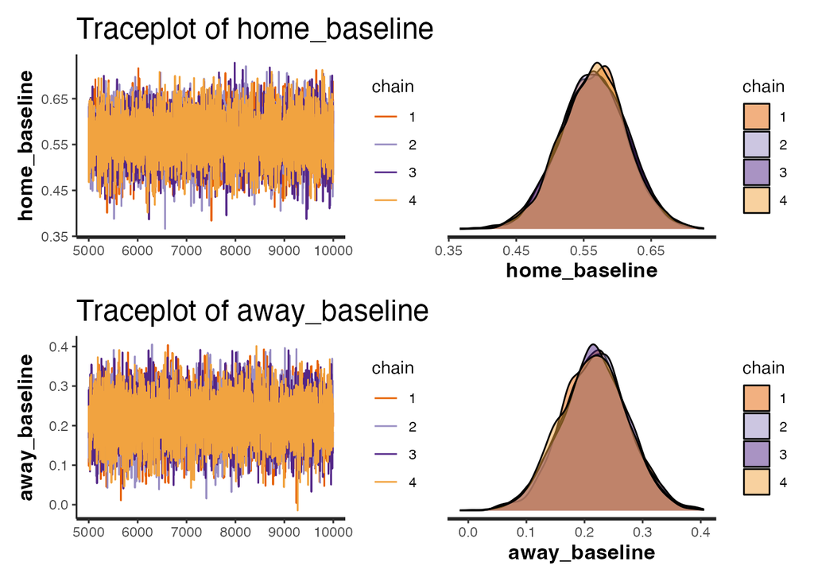

```r
plt_e <- stan_trace(fit2,
           pars = 'home_baseline',
           separate_chains = TRUE) + ggtitle('Traceplot of home_baseline')

plt_f <- stan_dens(fit2,
           pars = 'home_baseline',
           separate_chains = TRUE)

plt_g <- stan_trace(fit2,
           pars = 'away_baseline',
           separate_chains = TRUE) + ggtitle('Traceplot of away_baseline')

plt_h <- stan_dens(fit2,
           pars = 'away_baseline',
           separate_chains = TRUE)

(plt_e | plt_f) / (plt_g | plt_h)
```

`exp(home_baseline)`と`exp(away_baseline)`の差を見ると、ホームアドバンテージはホームチームのゴール数でおよそ0.5162821点多いことがわかる。

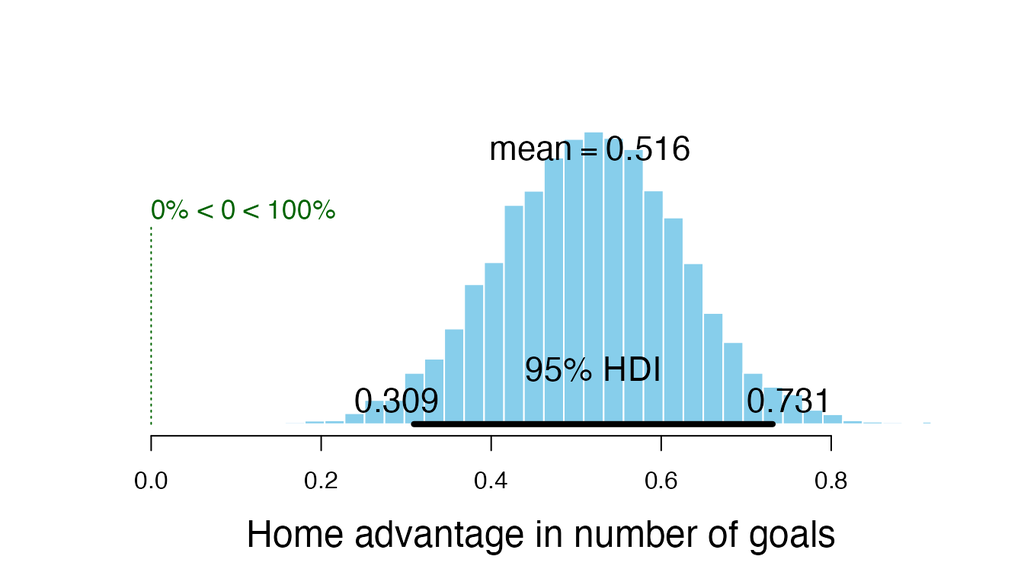

```r
plotPost(
  paramSampleVec = exp(ms2$home_baseline) - exp(ms2$away_baseline),
  compVal = 0,
  xlab = 'Home advantage in number of goals'
  )
```

最後に、バレンシア（ホームチーム）対セビージャ（アウェイチーム）のシミュレーション結果を見てみよう。

```r
plot_pred_comp2 <- function(home_team, away_team, ms) {
  old_par <- par(mfrow = c(2, 4))

  home_baseline <- ms$home_baseline
  away_baseline <- ms$away_baseline
  home_skill <- ms$skill[, which(teams == home_team)]
  away_skill <- ms$skill[, which(teams == away_team)]
  home_goals_sim <- rpois(length(ms$lp__), exp(home_baseline + home_skill - away_skill))
  away_goals_sim <- rpois(length(ms$lp__), exp(away_baseline + away_skill - home_skill))

  plot_goals(home_goals_sim, away_goals_sim)

  home_goals_obs <- d$HomeGoals[ d$HomeTeam == home_team & d$AwayTeam == away_team]
  away_goals_obs <- d$AwayGoals[ d$HomeTeam == home_team & d$AwayTeam == away_team]

  plot_goals(home_goals_obs, away_goals_obs)

  par(old_par)
}
```

バレンシア(Home) vs セビージャ(Away)を可視化する。

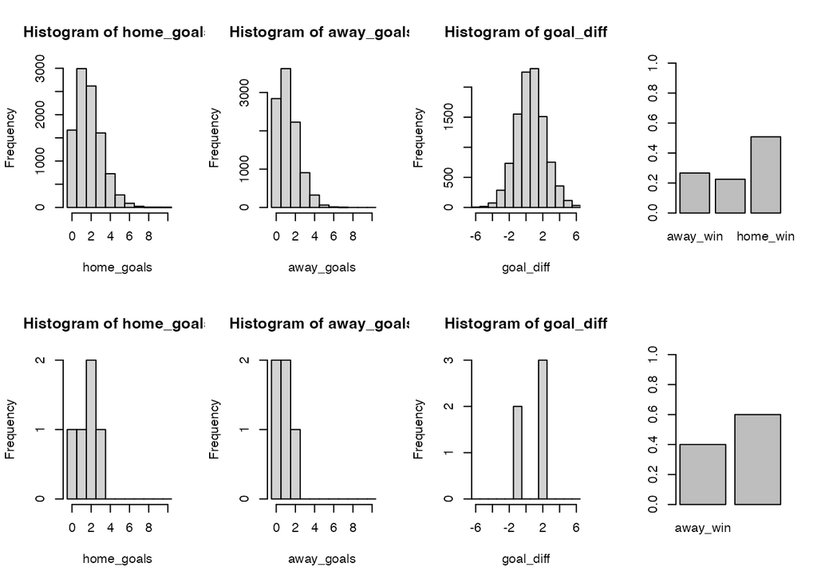

```r
plot_pred_comp2(home_team = 'FC Valencia', away_team = 'FC Sevilla', ms = ms2)
```

そして同様に、チームを入れ替えて、セビージャ(Home) vs バレンシア(Away)として可視化する。

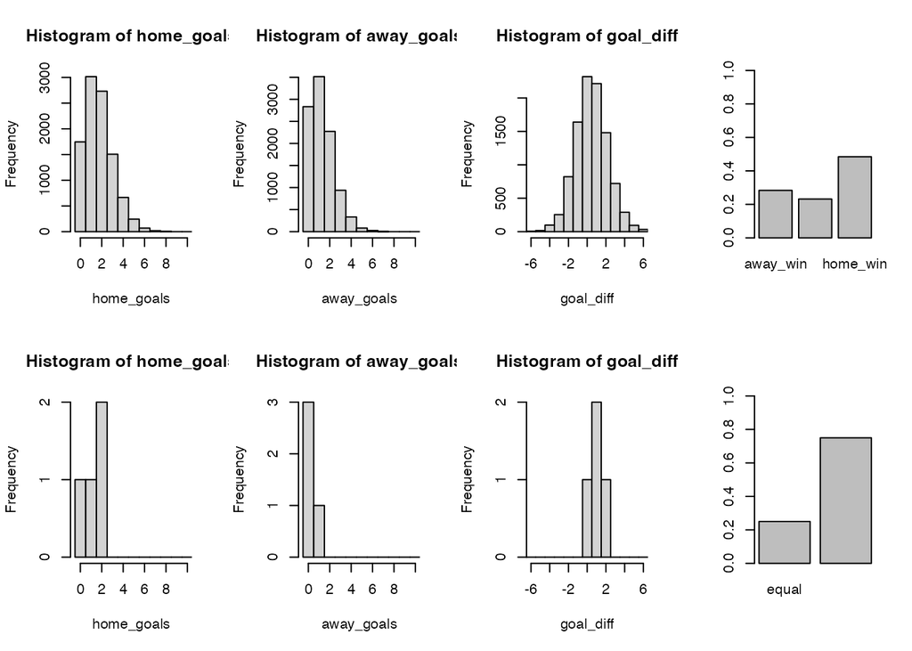

```r
plot_pred_comp2(home_team = 'FC Sevilla', away_team = 'FC Valencia', ms = ms2)
```

セビージャもバレンシアもホームチームとしてプレーした方が勝ちやすいことがわかる。

## Modeling Match Results: Iteration 3

データセット`laliga`には5つの異なるシーズンのデータが含まれており、現在のモデルの仮定は、チームがすべてのシーズンで同じスキルを持つとしている。これはおそらく現実的な仮定ではなく、チームはおそらく年ごとにパフォーマンスが異なるはずである。1部リーグから脱落した場合、`laliga`データのすべてのシーズンに参加していないチームもある。

- `Villarreal CF`: `2012/13`シーズンは1部リーグではない
- `Real Zaragoza`: `2008/09`シーズンは1部リーグではない
- `Real Valladolid`: `2010/11,2011/12`シーズンは1部リーグではない
- `CD Tenerife`: `2009/10`シーズンのみ1部リーグ

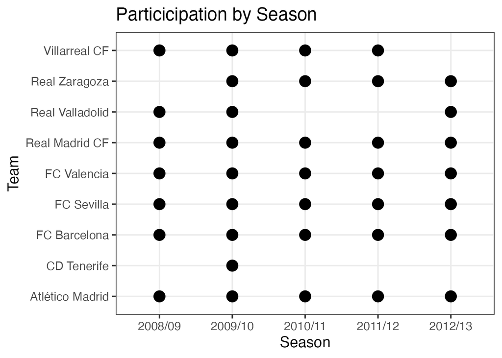

```r
plt_particicipation
```

チームのスキルの年ごとの変動を含めるように修正する。これは、各チームがシーズンごとに1つのスキル・パラメーターを持つようにし、シーズン$t$のチームのスキル・パラメタをシーズン$t+1$のチームのスキル・パラメタの事前分布に使用することによって、スキル・パラメタを引き継ぐことで行う。

$$\text{skill}_{t+1} \sim \text{Normal}(\text{skill}_{t},
\sigma_{\text{season}}^2)$$

ここで$\sigma^{2}_{season}$はデータ全体を使って推定したパラメタである。

```r
model3 <- stan_model('model3.stan')
```

モデルはこちら。

```
data {
  int<lower=1> n_games;
  int<lower=1> n_seasons;
  int<lower=1> n_teams;
  int<lower=1> Season[n_games];
  int<lower=1> HomeTeam[n_games];
  int<lower=1> AwayTeam[n_games];
  int<lower=0> HomeGoals[n_games];
  int<lower=0> AwayGoals[n_games];
}
parameters {
  vector[n_seasons] home_baseline;
  vector[n_seasons] away_baseline;
  matrix[n_teams, n_seasons] skill;
  real<lower=0> group_sigma;
  // real<lower=0> group_skill;
  real<lower=0> season_sigma;
}
transformed parameters {
  vector[n_games] lambda_home;
  vector[n_games] lambda_away;

  for (i in 1:n_games) {
    lambda_home[i] = exp(home_baseline[Season[i]] + skill[HomeTeam[i], Season[i]] - skill[AwayTeam[i], Season[i]]);
    lambda_away[i] = exp(away_baseline[Season[i]] + skill[AwayTeam[i], Season[i]] - skill[HomeTeam[i], Season[i]]);
  }
}
model {
  group_sigma ~ uniform(0, 1000);
  // group_skill ~ normal(0, 4);
  home_baseline[1] ~ normal(0, 4);
  away_baseline[1] ~ normal(0, 4);

  for (n in 1:n_teams) {
    skill[n, 1] ~ normal(0, group_sigma);
  }

  for (season_i in 2:n_seasons) {
    for (n in 1:n_teams) {
      skill[n, season_i] ~ normal(skill[n, season_i-1], season_sigma);
      }
    home_baseline[season_i] ~ normal(home_baseline[season_i-1], season_sigma);
    away_baseline[season_i] ~ normal(away_baseline[season_i-1], season_sigma);
  }

  for (i in 1:n_games) {
    HomeGoals[i] ~ poisson(lambda_home[i]);
    AwayGoals[i] ~ poisson(lambda_away[i]);
  }
}
```

`sampling()`関数でサンプリングする。

```r
fit3 <- sampling(object = model3, data = data_list, seed = 1989, chains = 4, iter = 10000, thin = 5)
```

推定結果を確認する。

```r
print(fit3, prob = c(0.025, 0.5, 0.975), digits_summary = 3)
```

```
## Inference for Stan model: anon_model.
## 4 chains, each with iter=10000; warmup=5000; thin=5;
## post-warmup draws per chain=1000, total post-warmup draws=4000.
##
##                      mean se_mean     sd     2.5%      50%    97.5% n_eff  Rhat
## home_baseline[1]    0.617   0.001  0.080    0.468    0.614    0.781  3338 1.002
## home_baseline[2]    0.615   0.001  0.066    0.490    0.614    0.748  2207 1.002
## home_baseline[3]    0.540   0.001  0.069    0.395    0.543    0.665  3079 1.000
## home_baseline[4]    0.486   0.002  0.083    0.306    0.492    0.634  1975 1.001
## home_baseline[5]    0.479   0.002  0.093    0.285    0.485    0.641  2391 1.000
## away_baseline[1]    0.256   0.001  0.087    0.090    0.254    0.431  3572 1.000
## away_baseline[2]    0.241   0.001  0.072    0.101    0.241    0.380  3472 1.000
## away_baseline[3]    0.197   0.001  0.077    0.034    0.198    0.340  3392 1.000
## away_baseline[4]    0.172   0.001  0.084   -0.007    0.177    0.326  3268 1.000
## away_baseline[5]    0.142   0.002  0.101   -0.078    0.148    0.320  2515 1.000
## skill[1,1]         -0.160   0.004  0.162   -0.478   -0.162    0.162  2093 1.001
## skill[1,2]         -0.224   0.004  0.163   -0.539   -0.225    0.088  2047 1.001
## skill[1,3]         -0.212   0.004  0.176   -0.564   -0.210    0.132  2179 1.001
## skill[1,4]         -0.197   0.004  0.187   -0.573   -0.197    0.168  2433 1.001
## skill[1,5]         -0.186   0.004  0.187   -0.556   -0.186    0.172  2429 1.000
## skill[2,1]         -0.023   0.003  0.158   -0.331   -0.024    0.298  2192 1.000
## skill[2,2]          0.000   0.003  0.156   -0.307   -0.003    0.314  2067 1.000
## skill[2,3]         -0.016   0.004  0.163   -0.343   -0.018    0.302  2055 1.000
## skill[2,4]         -0.009   0.004  0.168   -0.345   -0.009    0.315  2102 1.001
## skill[2,5]          0.025   0.004  0.180   -0.337    0.022    0.372  2325 1.000
## skill[3,1]          0.586   0.004  0.163    0.283    0.580    0.908  2077 1.001
## skill[3,2]          0.593   0.004  0.157    0.294    0.589    0.903  1895 1.001
## skill[3,3]          0.592   0.004  0.161    0.288    0.587    0.910  2071 1.000
## skill[3,4]          0.591   0.004  0.167    0.278    0.589    0.916  2017 1.001
## skill[3,5]          0.560   0.004  0.176    0.221    0.557    0.899  2215 1.001
## skill[4,1]         -0.023   0.003  0.160   -0.329   -0.025    0.295  2216 1.001
## skill[4,2]         -0.017   0.004  0.159   -0.322   -0.021    0.291  2001 1.001
## skill[4,3]         -0.060   0.004  0.166   -0.391   -0.063    0.269  2048 1.001
## skill[4,4]         -0.095   0.004  0.178   -0.454   -0.095    0.248  2035 1.002
## skill[4,5]         -0.094   0.004  0.200   -0.496   -0.092    0.290  2217 1.001
## skill[5,1]          0.002   0.003  0.160   -0.313   -0.001    0.311  2138 1.000
## skill[5,2]         -0.006   0.003  0.157   -0.315   -0.007    0.294  2016 1.000
## skill[5,3]         -0.005   0.004  0.161   -0.315   -0.008    0.312  2052 1.000
## skill[5,4]         -0.020   0.004  0.166   -0.347   -0.020    0.301  2057 1.001
## skill[5,5]         -0.044   0.004  0.176   -0.399   -0.043    0.301  2107 1.001
```

[output cut: 483 more lines]

```
## lambda_away[227]    1.268   0.005  0.235    0.824    1.264    1.739  2209 1.000
## lambda_away[228]    0.903   0.003  0.161    0.609    0.892    1.250  3321 1.000
## lambda_away[229]    1.167   0.004  0.205    0.794    1.155    1.584  3131 0.999
## lambda_away[230]    2.564   0.007  0.430    1.839    2.519    3.563  3673 1.001
## lambda_away[231]    0.955   0.003  0.185    0.613    0.941    1.343  3962 1.000
## lambda_away[232]    2.770   0.007  0.448    1.951    2.751    3.717  3790 1.000
## lambda_away[233]    1.253   0.004  0.220    0.869    1.237    1.734  3491 1.000
## lambda_away[234]    1.845   0.005  0.303    1.291    1.824    2.497  3987 0.999
## lambda_away[235]    1.351   0.005  0.248    0.895    1.337    1.871  2843 1.001
## lp__             -209.853   0.763 18.612 -240.026 -212.424 -168.641   595 1.007
##
## Samples were drawn using NUTS(diag_e) at Tue Jan 23 16:06:26 2024.
## For each parameter, n_eff is a crude measure of effective sample size,
## and Rhat is the potential scale reduction factor on split chains (at
## convergence, Rhat=1).
```

`season_sigma`パラメータのトレースプロットと分布を示している。

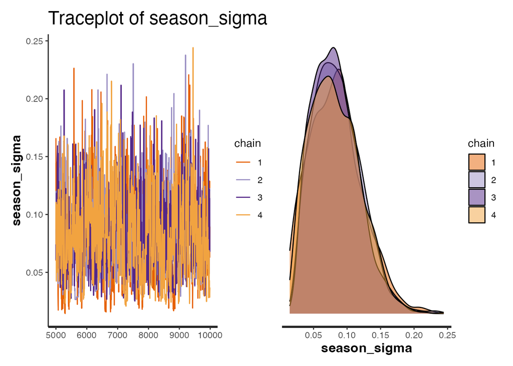

```r
plt_g <- stan_trace(fit3,
           pars = 'season_sigma',
           separate_chains = TRUE) + ggtitle('Traceplot of season_sigma')

plt_h <- stan_dens(fit3,
           pars = 'season_sigma',
           separate_chains = TRUE)

(plt_g | plt_h)
```

この部分は参考先のブログにないが、各チームのスキルの時系列の推移を可視化しておく。

```r
ms3 <- rstan::extract(fit3)
d_est <- data.frame()
for (n in 1:length(t)) {
  qua <- apply(ms3$skill[,n,], 2, quantile, prob  =  c(0.25, 0.5, 0.75))
  d_est <- rbind(
     d_est,
     data.frame(team = t[n], year = 2008:2012, t(qua), check.names = FALSE)
     )
}

d_est
```

```
##               team year         25%           50%         75%
## 1  Real Valladolid 2008 -0.26249083 -0.1615685632 -0.05934306
## 2  Real Valladolid 2009 -0.32337130 -0.2249560375 -0.12417559
## 3  Real Valladolid 2010 -0.32043656 -0.2101265006 -0.10693089
## 4  Real Valladolid 2011 -0.31286318 -0.1969365122 -0.07746688
## 5  Real Valladolid 2012 -0.30868639 -0.1857577812 -0.06633374
## 6  Atlético Madrid 2008 -0.12379327 -0.0241530309  0.07641963
## 7  Atlético Madrid 2009 -0.09880099 -0.0031711579  0.09873116
## 8  Atlético Madrid 2010 -0.11832397 -0.0175747215  0.08387438
## 9  Atlético Madrid 2011 -0.11358870 -0.0091338154  0.09300948
## 10 Atlético Madrid 2012 -0.08970033  0.0223445652  0.13654988
## 11    FC Barcelona 2008  0.48162524  0.5799015219  0.68305575
## 12    FC Barcelona 2009  0.49190267  0.5889136526  0.68709019
## 13    FC Barcelona 2010  0.49156226  0.5871710590  0.69009676
## 14    FC Barcelona 2011  0.48233123  0.5894673868  0.69308181
```

[output cut: 31 more lines]

バルセロナ、レアル・マドリード、アトレチコ・マドリードの3チームに色付けをして可視化する。緑はアトレチコ・マドリード、赤はレアル・マドリード、青がバルセロナである。今回のデータセットの時期における実績は下記の通りで、圧倒的にバルセロナ優位であり、可視化した結果とも一致する。レアルマドリードについては、2011-12に優勝するまでに徐々に力をつけていたことがわかる。

- 2008-09: バルセロナ / レアル・マドリード
- 2009-10: バルセロナ / レアル・マドリード
- 2010-11: バルセロナ / レアル・マドリード
- 2011-12: レアル・マドリード / バルセロナ
- 2012-13: バルセロナ / レアル・マドリード

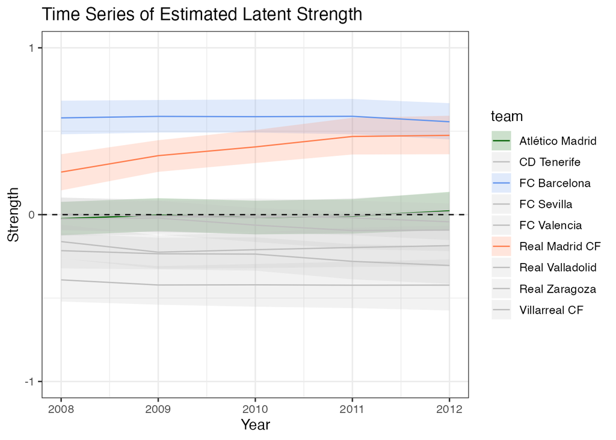

```r
col_team <- c('darkgreen', 'gray', 'cornflowerblue', 'gray', 'gray', 'coral', 'gray', 'gray', 'gray')
ggplot(data = d_est, aes(x = year, y = `50%`, group = team)) +
  theme_bw(base_size = 12) +
  geom_ribbon(aes(ymin = `25%`, ymax = `75%`, fill = team), alpha = 0.2) +
  geom_line(aes(col = team), linewidth = 0.5) +
  geom_hline(yintercept = 0, linetype = 'dashed') +
  labs(x = 'Year', y = 'Strength', title = 'Time Series of Estimated Latent Strength') +
  scale_x_continuous(breaks = 2008:2012) +
  scale_y_continuous(breaks = seq(-1,1,1), limit = c(-1, 1)) +
  scale_color_manual(values = col_team) +
  scale_fill_manual(values = col_team)
```

## Ranking the Teams of La Liga

2012/2013シーズンから推定されたスキル・パラメタを用いて、リーガ・エスパニョーラのチームをランキングする。ブログには下記の記載があるが、Stanで実行しているモデルではスキルを0に固定せず、特定の分布から生成されるゆるい仮定のもとで推定しているので、そのまま推定されたスキルを利用する。

> スキル・パラメタの値は、スキル・パラメタをゼロに「固定」したチームのスキルとの相対値なので、解釈が難しい。より解釈しやすい尺度に置き換えるために、まず全チームの平均スキルを差し引くことでスキルパラメータをゼロセンターにし、次にホームベースラインを加え、その結果を指数化。この再スケーリングされたスキルパラメーターは、ホームチームと対戦したときの予想ゴール数のスケールとなる。

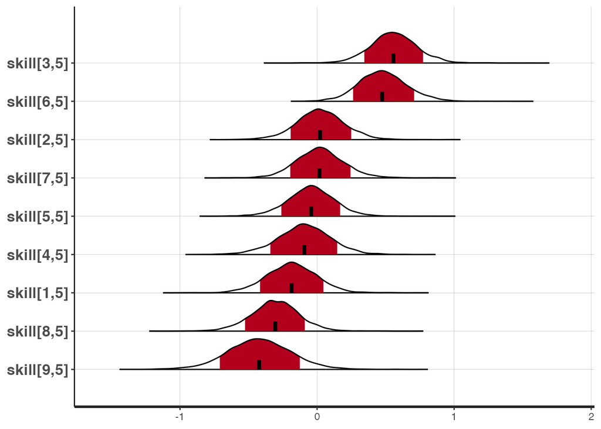

```r
tmp <- paste0('skill[', 1:length(teams), ',5]')
season1213_nm <- names(sort(get_posterior_mean(fit3, par = tmp)[, 'mean-all chains'], decreasing = TRUE))

stan_plot(
  fit3,
  pars = season1213_nm,
  show_density = TRUE,
  ci_level = 0.8,
  outer_level = 1,
  )
```

このままでは見ずらいが、チーム名は下記の通りで並んでいる。

```r
teams[as.numeric(sub(".*\\[([0-9]+).*", "\\1", season1213_nm))]
```

```
## [1] "FC Barcelona"    "Real Madrid CF"  "Atlético Madrid" "FC Valencia"
## [5] "FC Sevilla"      "Villarreal CF"   "Real Valladolid" "Real Zaragoza"
## [9] "CD Tenerife"
```

FCバルセロナは、レアルマドリードに対して、71.05%の確率でより良いチームである。

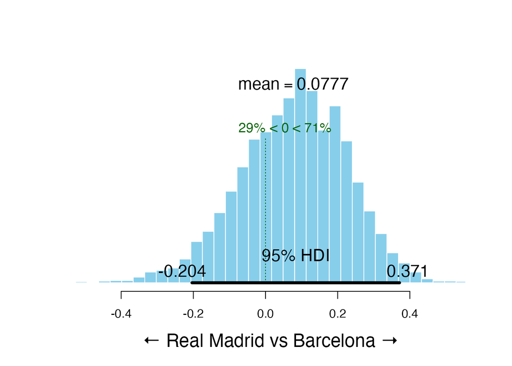

```r
plotPost(
  paramSampleVec = ms3$skill[,3,5] - ms3$skill[,6,5],
  compVal = 0,
  xlab = "← Real Madrid vs Barcelona →"
  )
```

## Predicting the End Game of La Liga 2012/2013

`laliga`のデータセットでは、2012/2013シーズンの最後の50試合の結果が欠落していた。モデルを用いて、これらの50試合の結果を予測し、シミュレーション。以下のRコードは、各試合(結果がわかっている試合とわかっていない試合の両方)について、いくつかの値を計算する。

- シミュレーションされたゴール数の最頻値、つまり最も可能性の高いゴール数。もし私たちが試合のゴール数に賭けることを求められたら、これを使う。
- シミュレーションゴール数の平均、これは試合における平均ゴール数の最良の推測。
- 各試合の最も可能性の高い試合結果。
- 信頼できるホームスコア、アウェイスコア、試合結果の分布からのランダムサンプル。これが、代替現実におけるリーガ・エスパニョーラの実際の展開予想である。

```r
dd <- laliga %>% filter(HomeTeam %in% t & AwayTeam %in% t)
n <- nrow(ms3$lp__)

m3_pred <- sapply(1:nrow(dd), function(i) {
  home_team <- which(teams == dd$HomeTeam[1])
  away_team <- which(teams == dd$AwayTeam[1])
  season <- which(seasons == dd$Season[1])

  home_skill <- ms3$skill[, home_team, season]
  away_skill <- ms3$skill[, away_team, season]

  home_baseline <- ms3$home_baseline[, season]
  away_baseline <- ms3$away_baseline[, season]

  home_goals <- rpois(n, exp(home_baseline + home_skill - away_skill))
  away_goals <- rpois(n, exp(away_baseline + away_skill - home_skill))

  home_goals_table <- table(home_goals)
  away_goals_table <- table(away_goals)

  match_results <- sign(home_goals - away_goals)
  match_results_table <- table(match_results)

  mode_home_goal <- as.numeric(names(home_goals_table)[which.max(home_goals_table)])
  mode_away_goal <- as.numeric(names(away_goals_table)[which.max(away_goals_table)])

  match_result <-  as.numeric(names(match_results_table)[which.max(match_results_table)])
  rand_i <- sample(seq_along(home_goals), 1)

  c(
    mode_home_goal = mode_home_goal,
    mode_away_goal = mode_away_goal,
    match_result = match_result,
    mean_home_goal = mean(home_goals),
    mean_away_goal = mean(away_goals),
    rand_home_goal = home_goals[rand_i],
    rand_away_goal = away_goals[rand_i],
    rand_match_result = match_results[rand_i]
  )

})
m3_pred <- t(m3_pred)
head(m3_pred, 30)
```

```
##       mode_home_goal mode_away_goal match_result mean_home_goal mean_away_goal
##  [1,]              1              1            1        1.64725        1.49800
##  [2,]              1              1            1        1.69300        1.48000
##  [3,]              1              1            1        1.63300        1.47375
##  [4,]              1              1            1        1.60175        1.48050
##  [5,]              1              1            1        1.66300        1.47350
##  [6,]              1              1            1        1.64075        1.50950
##  [7,]              1              1            1        1.62525        1.50275
##  [8,]              1              1            1        1.59325        1.49575
##  [9,]              1              1            1        1.64275        1.52100
## [10,]              1              1            1        1.65325        1.48200
## [11,]              1              1            1        1.65225        1.52575
## [12,]              1              1            1        1.62375        1.48800
## [13,]              1              1            1        1.64625        1.52400
## [14,]              1              1            1        1.66550        1.50800
```

[output cut: 47 more lines]

データ中のゴール数の分布を、全試合の予測最頻値、平均値、ランダムゴール数を比較してみる。 まず、ホームチームの観測された実際のゴール数分布。

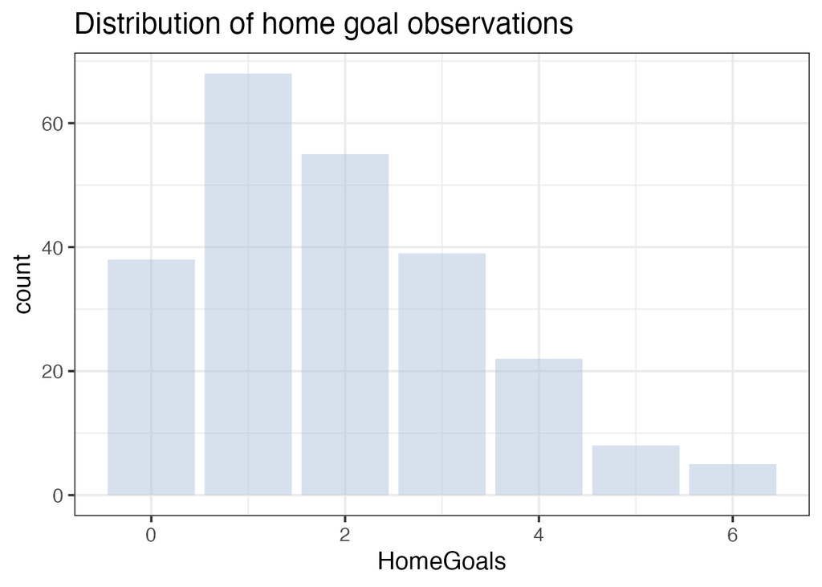

```r
ggplot() +
  theme_bw(base_size = 15) +
  geom_bar(data = dd, aes(HomeGoals), fill = 'lightsteelblue', alpha = 1/2) +
  labs(title = 'Distribution of home goal observations')
```

ほとんどすべての試合で、最も可能性の高いゴール数は1つ。実際、リーガ・エスパニョーラの試合について何も知らない場合、ホームチームの1ゴールに賭けることは、100 %の確率でベストベットです。

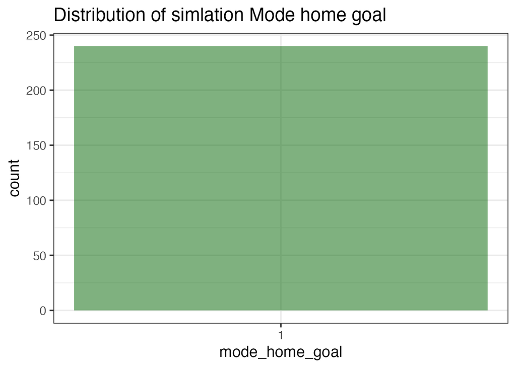

```r
ggplot() +
  theme_bw(base_size = 15) +
  geom_bar(data = data.frame(m3_pred), aes(mode_home_goal), fill = 'darkgreen', alpha = 1/2) +
  scale_x_continuous(breaks = seq(0, 10, 1)) +
  labs(title = 'Distribution of simlation Mode home goal')
```

ほとんどの試合で、予想ゴール数は1.6前後。つまり、最も安全なベットが1ゴールだったとしても、2ゴール前後が予想される。

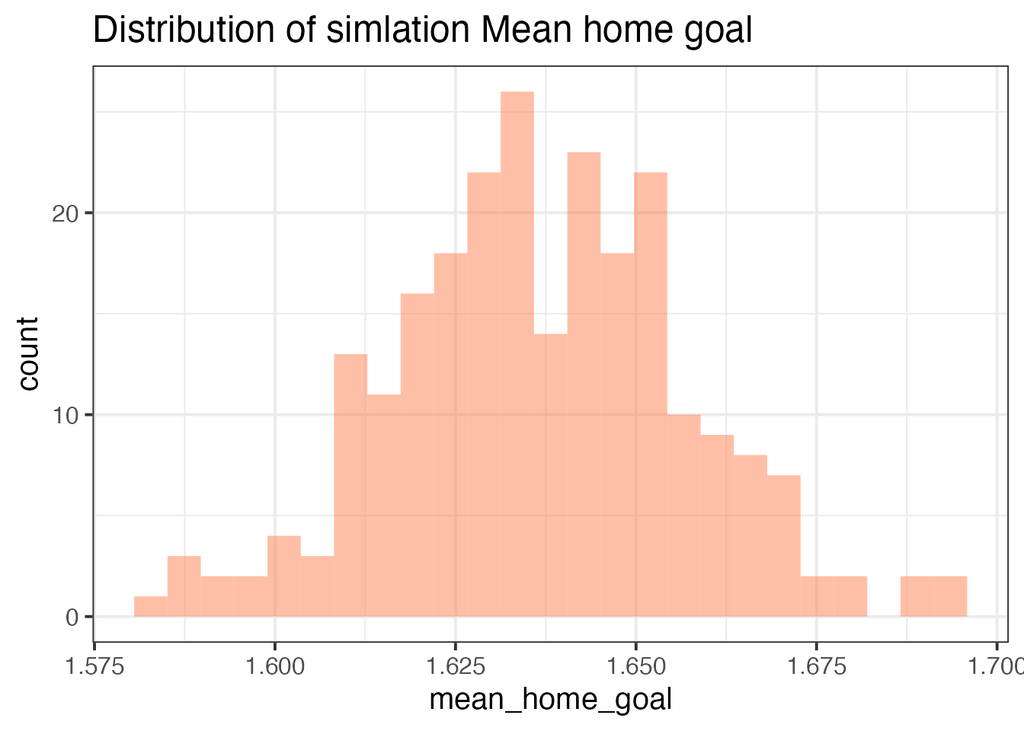

```r
ggplot() +
  theme_bw(base_size = 15) +
  geom_histogram(data = data.frame(m3_pred), aes(mean_home_goal), fill = 'coral', alpha = 1/2, bins = 25) +
  labs(title = 'Distribution of simlation Mean home goal')
```

最頻値と平均ゴール数の分布は、実際のゴール数とは似ても似つかない。しかし、ランダム化されたゴール数(各試合のゴール数がその試合のホームゴール数分布からランダムに抽出されたもの)の分布は、実際のホームゴール数に似ていると予想される。

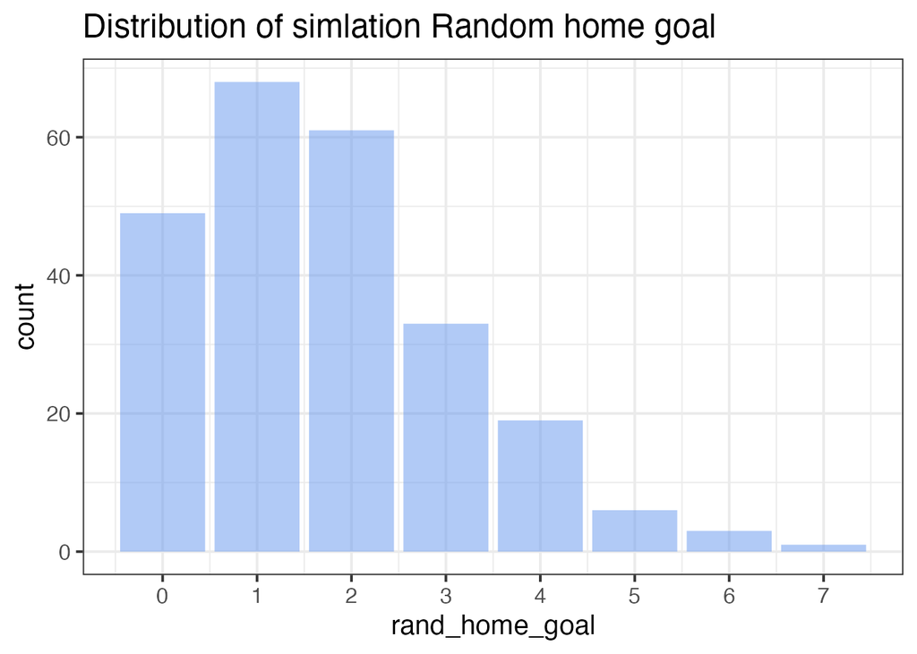

```r
ggplot() +
  theme_bw(base_size = 15) +
  geom_bar(data = data.frame(m3_pred), aes(rand_home_goal), fill = 'cornflowerblue', alpha = 1/2) +
  scale_x_continuous(breaks = seq(0,10,1)) +
  labs(title = 'Distribution of simlation Random home goal')
```

また、モデルがどの程度データを予測するかを見ることもできる。これはおそらくクロスバリデーションを用いて行うべきですが、有効なパラメータの数はデータポイントの数よりはるかに少ないので、直接比較することで少なくとも適切な範囲の予測精度を推定することができる。

```r
list(
  mean(laliga$HomeGoals == m3_pred[ , "mode_home_goal"], na.rm = TRUE),
  mean((laliga$HomeGoals - m3_pred[ , "mean_home_goal"])^2, na.rm = TRUE)
)
```

```
## [[1]]
## [1] 0.3259459
##
## [[2]]
## [1] 1.816843
```

つまり平均して、モデルは正しいホームゴール数を 33 %の確率で予測し、平均二乗誤差 1.82 の平均ゴール数を推測する。

次に、実際の試合結果と予測された試合結果を見てみる。下のグラフは、1がホームチームの勝利、0が引き分け、-1がアウェイチームの勝利で、データの試合結果を示している。

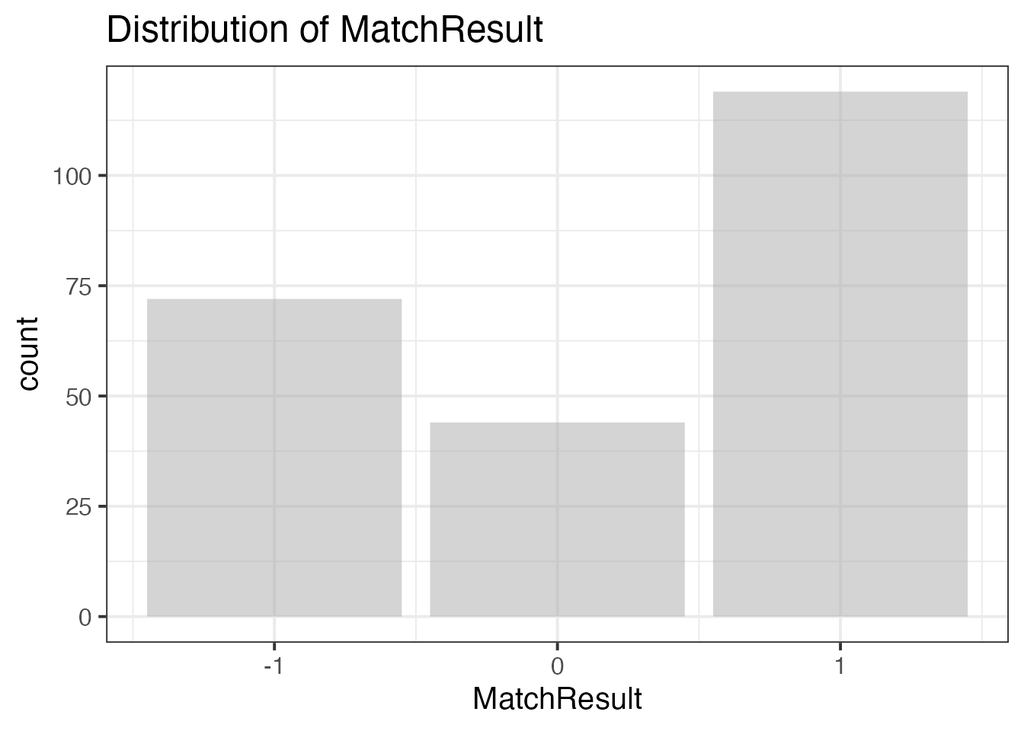

```r
ggplot() +
  theme_bw(base_size = 15) +
  geom_bar(data = dd, aes(MatchResult), fill = 'darkgray', alpha = 1/2) +
  scale_x_continuous(breaks = seq(-1, 1, 1)) +
  labs(title = 'Distribution of MatchResult')
```

ほとんどすべての試合において、最も安全な賭けはホームチームに賭けることである。引き分けは珍しくないが、最も安全な賭けであることはない。

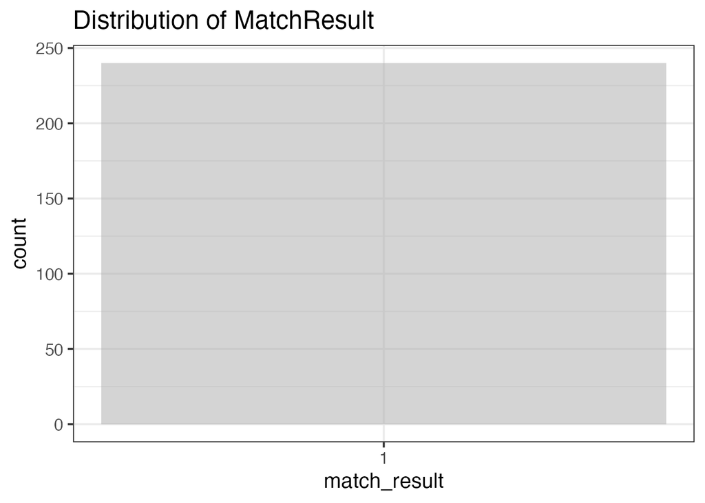

```r
ggplot() +
  theme_bw(base_size = 15) +
  geom_bar(data = data.frame(m3_pred), aes(match_result), fill = 'darkgray', alpha = 1/2) +
  scale_x_continuous(breaks = seq(-1, 1, 1)) +
  labs(title = 'Distribution of MatchResult')
```

ホームゴール数の場合と同様に、ランダム化された試合結果は、実際の試合結果と似た分布を持つ(データを限定しているので、あまり似ていないが)。

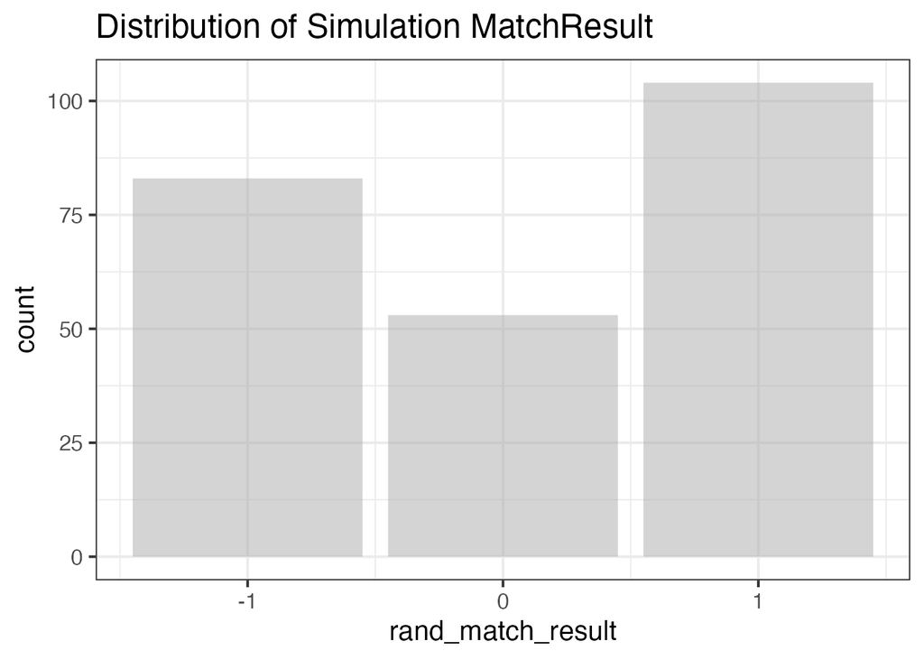

```r
ggplot() +
  theme_bw(base_size = 15) +
  geom_bar(data = data.frame(m3_pred), aes(rand_match_result), fill = 'darkgray', alpha = 1/2) +
  scale_x_continuous(breaks = seq(-1, 1, 1)) +
  labs(title = 'Distribution of Simulation MatchResult')
```

```r
mean(laliga$MatchResult == m3_pred[ , "match_result"], na.rm = TRUE)
```

```
## [1] 0.5005405
```

さて、モデルがリーガ・エスパニョーラの歴史を合理的に予測することをチェックしたので、リーガ・エスパニョーラの終盤戦を予測する。以下のコードは、終盤戦の予測されたモードと平均ゴール数、そして各ゲームの予測された勝者を表示する。

```r
laliga_forecast <- dd[is.na(dd$HomeGoals), c("Season", "Week", "HomeTeam", "AwayTeam")]
m3_forecast <- m3_pred[is.na(dd$HomeGoals),]
laliga_forecast$mean_home_goals <- round(m3_forecast[,"mean_home_goal"], 1)
laliga_forecast$mean_away_goals <- round(m3_forecast[,"mean_away_goal"], 1)
laliga_forecast$mode_home_goals <- m3_forecast[,"mode_home_goal"]
laliga_forecast$mode_away_goals <- m3_forecast[,"mode_away_goal"]
laliga_forecast$predicted_winner <- ifelse(m3_forecast[ , "match_result"] == 1, laliga_forecast$HomeTeam,
                                           ifelse(m3_forecast[ , "match_result"] == -1, laliga_forecast$AwayTeam, "Draw"))

rownames(laliga_forecast) <- NULL
print(xtable::xtable(laliga_forecast, align="cccccccccc"), type="html")
```

|  | Season | Week | HomeTeam | AwayTeam | mean_home_goals | mean_away_goals | mode_home_goals | mode_away_goals | predicted_winner |
| --- | --- | --- | --- | --- | --- | --- | --- | --- | --- |
| 1 | 2012/13 | 34 | Real Madrid CF | Real Valladolid | 1.60 | 1.50 | 1.00 | 1.00 | Real Madrid CF |
| 2 | 2012/13 | 35 | Atlético Madrid | FC Barcelona | 1.60 | 1.50 | 1.00 | 1.00 | Atlético Madrid |
| 3 | 2012/13 | 36 | FC Barcelona | Real Valladolid | 1.60 | 1.50 | 1.00 | 1.00 | FC Barcelona |
| 4 | 2012/13 | 38 | FC Sevilla | FC Valencia | 1.70 | 1.50 | 1.00 | 1.00 | FC Sevilla |
| 5 | 2012/13 | 38 | Real Zaragoza | Atlético Madrid | 1.60 | 1.50 | 1.00 | 1.00 | Real Zaragoza |

これらの予測は、勝者になる可能性の高いチームに賭けるには良いが、実際の終盤戦がどのように展開するかは反映していない。

`m3_pred`の`match_result`は`home_goals - away_goals`の差を`sign()`関数で変換し、ホームゴールが多ければホームチームの勝利(=1)、アウェイチームのゴールが多ければアウェイチームの勝利(=-1)として、MCMCのサンプル分シュミレーションした結果を集計し、最も頻度が多いものが`match_result`となる。

最後に、先に計算したシミュレーション結果を表示して、リーガ・エスパニョーラ終盤戦の可能なバージョンを見る。つまり、各チームのスキルをもとにしてポアソン分布で発生させたゴール数の試合結果を見る。

```r
laliga_sim <- dd[is.na(dd$HomeGoals), c("Season", "Week", "HomeTeam", "AwayTeam")]
laliga_sim$home_goals <- m3_forecast[,"rand_home_goal"]
laliga_sim$away_goals <- m3_forecast[,"rand_away_goal"]
laliga_sim$winner <- ifelse(m3_forecast[ , "rand_match_result"] == 1, laliga_forecast$HomeTeam,
                            ifelse(m3_forecast[ , "rand_match_result"] == -1, laliga_forecast$AwayTeam, "Draw"))

rownames(laliga_sim) <- NULL
print(xtable::xtable(laliga_sim, align="cccccccc"), type="html")
```

|  | Season | Week | HomeTeam | AwayTeam | home_goals | away_goals | winner |
| --- | --- | --- | --- | --- | --- | --- | --- |
| 1 | 2012/13 | 34 | Real Madrid CF | Real Valladolid | 3.00 | 4.00 | Real Valladolid |
| 2 | 2012/13 | 35 | Atlético Madrid | FC Barcelona | 1.00 | 3.00 | FC Barcelona |
| 3 | 2012/13 | 36 | FC Barcelona | Real Valladolid | 4.00 | 0.00 | FC Barcelona |
| 4 | 2012/13 | 38 | FC Sevilla | FC Valencia | 4.00 | 0.00 | FC Sevilla |
| 5 | 2012/13 | 38 | Real Zaragoza | Atlético Madrid | 2.00 | 2.00 | Draw |

## Calculating the Predicted Payout for Sevilla vs Valencia, 2013-06-01

ベイズ・モデリングとMCMCサンプリングを使用することのパワーの1つは、いったんパラメータのMCMCサンプルが得られれば、パラメタ推定値の不確実性を保持したまま、これらの推定値から得られる任意の量を計算するのが簡単だということ。それでは、セビージャ対バレンシアの試合のゴール数の予測分布を計算するためにMCMCサンプルを使うことから始める。

```r
n <- nrow(ms3$lp__)
home_team <- which(teams == "FC Sevilla")
away_team <- which(teams == "FC Valencia")
season <- which(seasons == "2012/13")

home_skill <- ms3$skill[, home_team, season]
away_skill <- ms3$skill[, away_team, season]
home_baseline <- ms3$home_baseline[, season]
away_baseline <- ms3$away_baseline[, season]

home_goals <- rpois(n, exp(home_baseline + home_skill - away_skill))
away_goals <- rpois(n, exp(away_baseline + away_skill - home_skill))
```

この2つの分布の要約を見ると、接戦になるだろうが、ホームチームのセビージャがわずかに有利であることがわかる。

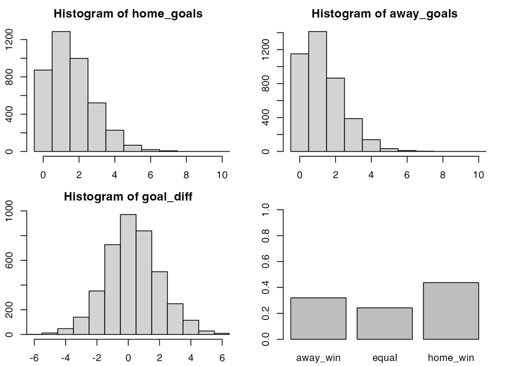

```r
old_par <- par(mfrow = c(2, 2), mar=rep(2.2, 4))
plot_goals(home_goals, away_goals)
```

```r
par(old_par)
```

この記事を書いている時点（2013-05-28）では、ベッティングサイトwww.betsson.comでこのゲームの結果に賭けた場合、以下のようなペイアウト（つまり、ベットが成功した場合、いくら戻ってくるか）が得られます：

```
 Sevilla  Draw  Valencia
   3.2    3.35    2.15
```

シミュレーションしたゴール数分布を使って、私のモデルの予測ペイアウトを計算することができる。

```r
1 / c(
  Sevilla =  mean(home_goals > away_goals),
  Draw = mean(home_goals == away_goals),
  Valencia = mean(home_goals < away_goals)
  )
```

```
##  Sevilla     Draw Valencia
## 2.287021 4.119464 3.125000
```

私のモデルは2.29のペイアウト（つまり、セビージャの勝利の可能性が高い）を予測しているのに対し、betsson.comは3.2というはるかに高いペイアウトを示しているので、私は明らかにセビージャに賭けるべきだ。言い換えると、自作のモデルはホームのセビージャが勝つ予測しているので、セビージャのペイアウトが小さいが、betsson.comはセビージャが負けると予想しているため、ペイアウトが高い。

最終的なゴールの結果にベットすることも可能なので、異なるゴールの結果に対して私のモデルが予測するペイアウトを計算する。

```r
goals_payout <- plyr::laply(0:6, function(home_goal) {
  plyr::laply(0:6, function(away_goal) {
    1 / mean(home_goals == home_goal & away_goals  == away_goal)
  })
})

colnames(goals_payout) <- paste("Valencia", 0:6, sep=" - ")
rownames(goals_payout) <- paste("Sevilla", 0:6, sep=" - ")
goals_payout <- round(goals_payout, 1)
print(xtable::xtable(goals_payout, align="cccccccc"), type="html")
```

|  | Valencia - 0 | Valencia - 1 | Valencia - 2 | Valencia - 3 | Valencia - 4 | Valencia - 5 | Valencia - 6 |
| --- | --- | --- | --- | --- | --- | --- | --- |
| Sevilla - 0 | 16.90 | 12.70 | 20.90 | 42.60 | 142.90 | 666.70 | 4000.00 |
| Sevilla - 1 | 11.00 | 8.70 | 14.20 | 33.30 | 105.30 | 250.00 | 1000.00 |
| Sevilla - 2 | 14.00 | 11.80 | 18.20 | 38.80 | 102.60 | 666.70 | 1333.30 |
| Sevilla - 3 | 25.00 | 22.50 | 35.70 | 93.00 | 166.70 | 2000.00 | 2000.00 |
| Sevilla - 4 | 51.90 | 51.30 | 100.00 | 181.80 | 444.40 | 2000.00 | Inf |
| Sevilla - 5 | 222.20 | 129.00 | 363.60 | 1000.00 | 4000.00 | 4000.00 | 4000.00 |
| Sevilla - 6 | 666.70 | 500.00 | 666.70 | Inf | Inf | Inf | Inf |

最も可能性の高い結果は1 - 1で、予想配当は8.7。betsson.comもこれに同意し、このベットの最低配当である5.3を提供している。十分ではない！bettson.comのペイアウトを見ると、Sevilla - Valencia: 2 - 0のペイアウトは16.0と、私の予想ペイアウトである14よりはるかに良い。これは私の予想配当である 14 よりもはるかに良い配当である！

## Wrap-up

私のモデルには多くの利点があると思う。概念的に非常にシンプルで、理解しやすく、実装しやすく、拡張しやすい。データのパターンと分布をよく捉えている。これによって、リーガ・エスパニョーラのどのシーズンのどのチームとの試合でも、どのような結果になるかの確率を計算することができる。